# R Notebook

# Hipotese 3

One common benchmark is the cpu utilization. To measure it we used
$$usage = \frac{cpu\_time}{max(arrival\_time+turnaround)}$$
We believe that, for a system with mixed short and long processes, SRTF will have an overall higher CPU usage because it will dispatch more processes to the io queue. On the other hand, schedulers like FCFS will take longer to complete the workload, having less cpu usage, because the processes will accumulate in the ready wait queue while the io queue is empty.

To test this hypothesis we will use a paired T-test.

Formaly, we have:
$$H_0 = usage(SRTF) = usage(FCFS)\\
H_1 = usage(SRTF) > usage(FCFS)$$

Quick insight of the workload

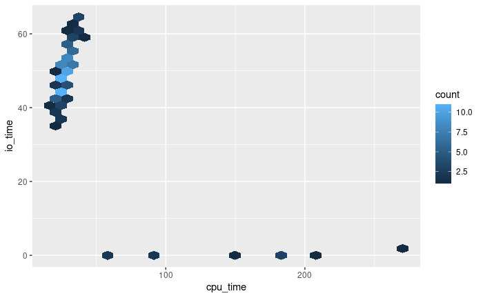

```r
library(tidyverse)
library(ggpubr)
library(rstatix)
source("utils.R")
wk_name = "h3"
pr = load_proc(wk_name)
ggplot(pr,aes(cpu_time,io_time)) + geom_hex()
```

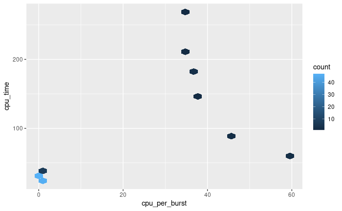

```r
ggplot(pr,aes(cpu_per_burst,cpu_time)) + geom_hex()
```

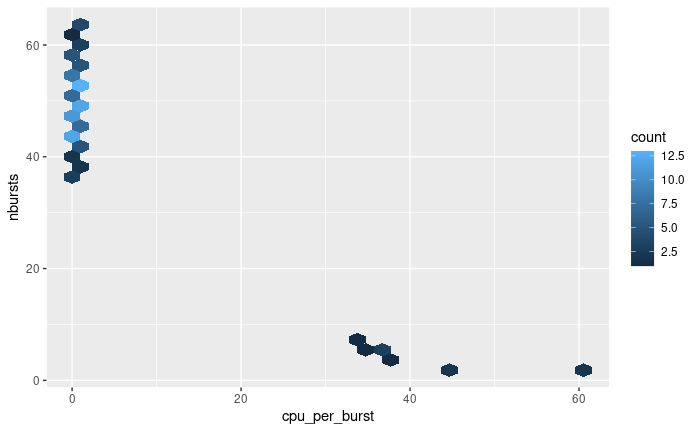

```r
ggplot(pr,aes(cpu_per_burst,nbursts)) + geom_hex()
```

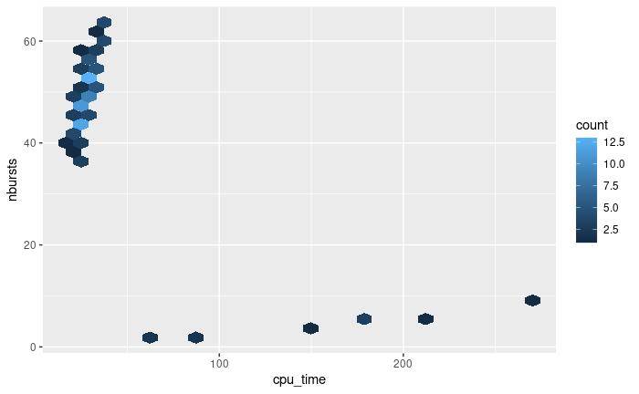

```r
ggplot(pr,aes(cpu_time,nbursts)) + geom_hex()
```

Data preparation

```r
wk = load_workload(wk_name,all_seeds = TRUE) %>% filter(seed != 91)
wk = calc_usage(wk)
```

Even tough our n > 30, we will still check normality (in the case that we change our data in the future)

```r
fcfs = wk[wk$scheduler=="FCFS",]
srtf = wk[wk$scheduler=="SRTF",]

shapiro.test(fcfs$usage)
```

```
    Shapiro-Wilk normality test

data:  fcfs$usage
W = 0.98957, p-value = 0.5032
```

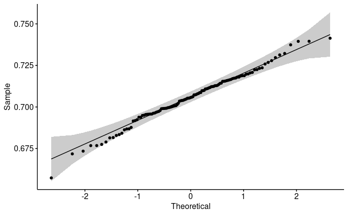

```r
ggqqplot(fcfs$usage)
```

```r
shapiro.test(srtf$usage)
```

```
    Shapiro-Wilk normality test

data:  srtf$usage
W = 0.99123, p-value = 0.654
```

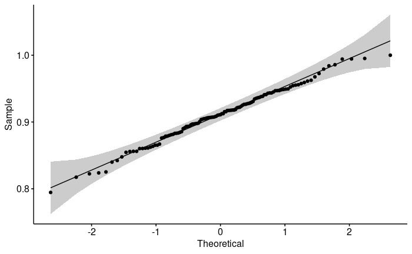

```r
ggqqplot(srtf$usage)
```

The T-test yielded the following results:

```r
t.test(
  fcfs$usage, srtf$usage, paired = TRUE, alternative = "less"
)
```

```
    Paired t-test

data:  fcfs$usage and srtf$usage
t = -82.26, df = 118, p-value < 2.2e-16
alternative hypothesis: true difference in means is less than 0
95 percent confidence interval:
       -Inf -0.2008777
sample estimates:
mean of the differences
             -0.2050095
```

As expected, the p-value is lower than our confidence level of 0.05, so we reject the null hypothesis, meaning the average of used cpu is significantly different between the FCFS and SRTF.

## Analysis

The workloads were formed by merging two runs of the generator script. Our idea was the following: schedulers that switched contexts more often would offload more processes to the io queue. Ideally, both the cpu and the IO controller would be working at the same time, but in a first come first served fashion the queue would build up on the cpu/io queue, depending on which was slower. Following this logic we can broaden out hypothesis and reformulate it:
$$H_0 = usage(SRTF) = usage(SJF) = usage(RR)\\
H_1 = \exists{i,j}: usage_i \neq usage_j$$

Quick visualization with boxplots:

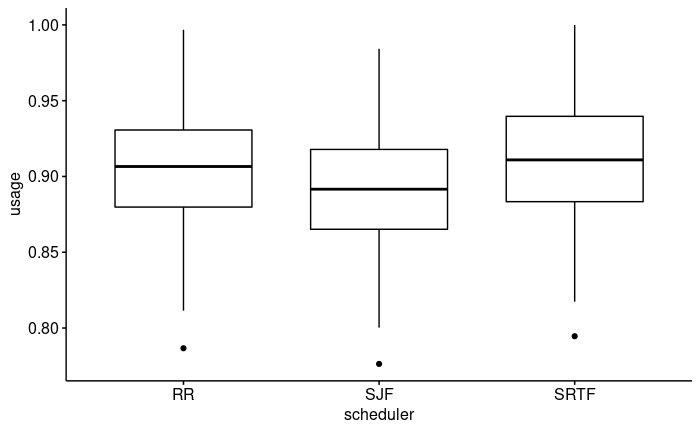

```r
wk = filter(wk,scheduler != "FCFS")
wk$scheduler = as.factor(wk$scheduler)
ggboxplot(wk,x="scheduler",y="usage")
```

## checking assumtions

### outliers

```r
t <- wk %>%
  group_by(scheduler) %>%
  select(scheduler,seed,usage) %>%
  identify_outliers(usage)
```

As seed 91 had one extreme outlier (further research necessary) we removed that seed from the workload

### Shapiro test

```r
wk <- filter(wk,seed != 91)

wk %>%
  group_by(scheduler) %>%
  shapiro_test(usage)
```

| scheduler | variable | statistic | p |
| --- | --- | --- | --- |
| RR | usage | 0.9911870 | 0.6498467 |
| SJF | usage | 0.9907185 | 0.6060078 |
| SRTF | usage | 0.9912310 | 0.6539960 |

as p > 0.05 for all the schedulers, we can assume normality.

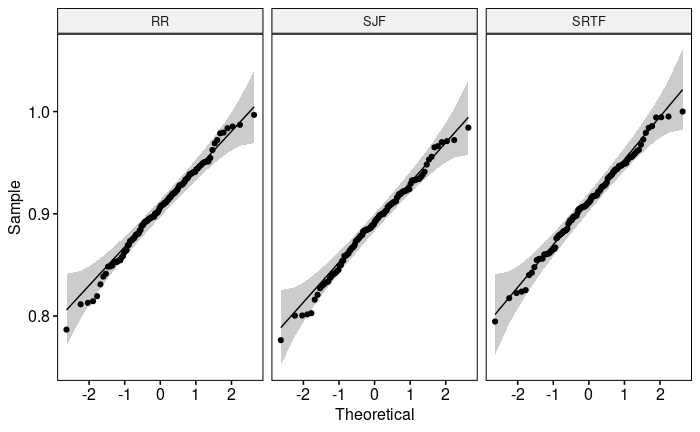

```r
ggqqplot(wk,"usage",facet.by = "scheduler")
```

## Repeated measures ANOVA

Check sphericity (variance of the differences between groups should be equal)

```r
wk <- load_workload(wk_name, all_seeds = TRUE) %>% filter(seed != 91)
wk <- calc_usage(wk) %>%
  filter(scheduler != "FCFS") %>%
  convert_as_factor(seed,scheduler) %>%
  ungroup() %>%
  select(seed,scheduler,usage)
res.aov <- anova_test(data=wk, dv=usage, wid=seed, within = scheduler)
get_anova_table(res.aov)
```

```
ANOVA Table (type III tests)

     Effect DFn    DFd        F         p p<.05   ges
1 scheduler 1.7 200.11 2135.954 2.97e-129     * 0.044
```

```r
pwc <- wk %>%
  pairwise_t_test(
    usage ~ scheduler, paired = TRUE, p.adjust.method = "bonferroni"
  )
pwc
```

|  | .y. | group1 | group2 | n1 | n2 | statistic | df | p | p.adj | p.adj.signif |
| --- | --- | --- | --- | --- | --- | --- | --- | --- | --- | --- |
| 1 | usage | RR | SJF | 119 | 119 | 56.29088 | 118 | 4.22e-87 | 1.27e-86 | **** |
| 2 | usage | RR | SRTF | 119 | 119 | -19.23029 | 118 | 3.62e-38 | 1.09e-37 | **** |
| 3 | usage | SJF | SRTF | 119 | 119 | -54.92674 | 118 | 6.87e-86 | 2.06e-85 | **** |

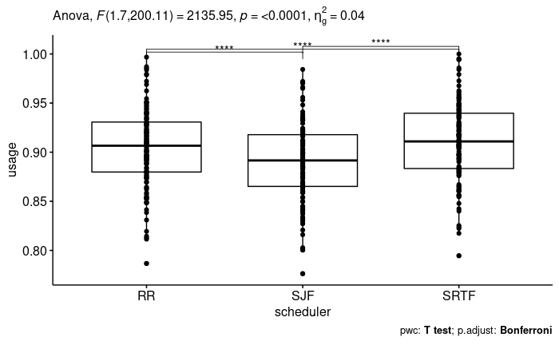

```r
bxp <- ggboxplot(wk, x = "scheduler", y = "usage", add = "point")
pwc <- pwc %>% add_xy_position(x = "scheduler")
bxp +
  stat_pvalue_manual(pwc) +
  labs(
    subtitle = get_test_label(res.aov, detailed = TRUE),
    caption = get_pwc_label(pwc)
  )
```

These conclusions become more apparent with the following visualization:

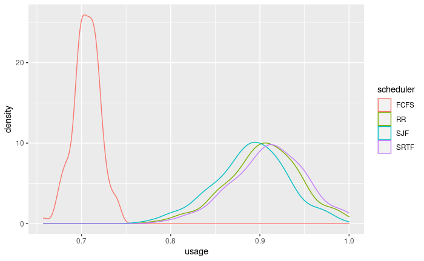

```r
wk = load_workload("h3",all_seeds = TRUE)
wk = calc_usage(wk) %>% filter(seed != 91)
ggplot(wk,aes(usage,color=scheduler)) + geom_density()
```

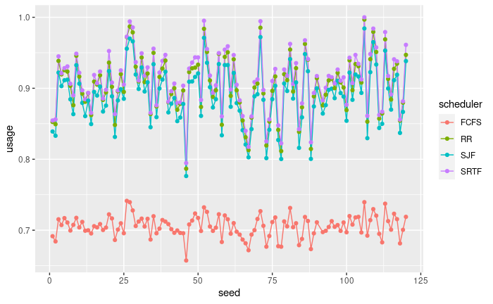

```r
ggplot(wk, aes(x=seed, y=usage, color=scheduler)) + geom_line() + geom_point()
```

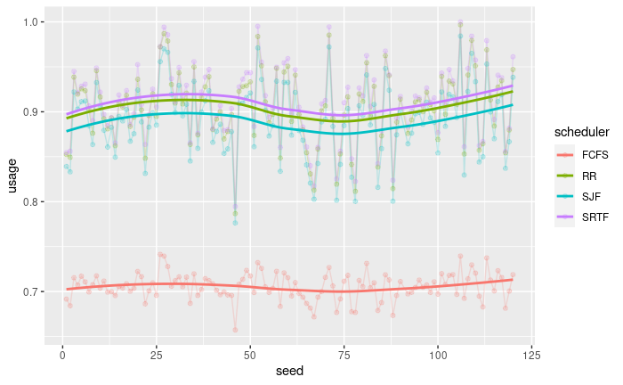

```r
ggplot(wk, aes(x=seed, y=usage, color=scheduler)) + geom_line(alpha=0.2) + geom_point(alpha=0.2) + geom_smooth(se=FALSE)
```